신록예찬's 블로그

# (노트) COVID 19 CT scans

미완성

Aug 4, 2021 • 신록예찬 • 2 min read

파이썬 논문연구

- Ref
- Download data
- Unzip
- Import
- Load Data
- Plot
- Discussion with 하영

### Ref

`-` https://www.kaggle.com/andrewmvd/covid-19-ct-scans-getting-started

### Download data

아래에 접속한다.

https://www.kaggle.com/andrewmvd/covid19-ct-scans

우측상단의 Download (7GB) 를 누름.

로그인이 필요할 수 있다.

### Unzip

압축을 풀고 싶은 폴더 (`/home/khy` 에 푸는것을 추천함) 로 가서 아래를 실행

```
(base) cgb3@cgb3:~$  unzip archive.zip -d covid19-ct-scans
```

여기에서 archive.zip 은 다운받은 파일 이름, covid19-ct-scans는 압축푼 파일들을 담을 폴더

### Import

```python
import glob
import pandas  as pd
import numpy   as np
import nibabel as nib
import matplotlib.pyplot as plt
```

### Load Data

```python
raw_data = pd.read_csv('/home/cgb3/covid19-ct-scans/metadata.csv')
raw_data.sample(5)
```

|  | ct_scan | lung_mask | infection_mask | lung_and_infection_mask |
| --- | --- | --- | --- | --- |
| 17 | ../input/covid19-ct-scans/ct_scans/radiopaedia... | ../input/covid19-ct-scans/lung_mask/radiopaedi... | ../input/covid19-ct-scans/infection_mask/radio... | ../input/covid19-ct-scans/lung_and_infection_m... |
| 15 | ../input/covid19-ct-scans/ct_scans/radiopaedia... | ../input/covid19-ct-scans/lung_mask/radiopaedi... | ../input/covid19-ct-scans/infection_mask/radio... | ../input/covid19-ct-scans/lung_and_infection_m... |
| 7 | ../input/covid19-ct-scans/ct_scans/coronacases... | ../input/covid19-ct-scans/lung_mask/coronacase... | ../input/covid19-ct-scans/infection_mask/coron... | ../input/covid19-ct-scans/lung_and_infection_m... |
| 1 | ../input/covid19-ct-scans/ct_scans/coronacases... | ../input/covid19-ct-scans/lung_mask/coronacase... | ../input/covid19-ct-scans/infection_mask/coron... | ../input/covid19-ct-scans/lung_and_infection_m... |
| 4 | ../input/covid19-ct-scans/ct_scans/coronacases... | ../input/covid19-ct-scans/lung_mask/coronacase... | ../input/covid19-ct-scans/infection_mask/coron... | ../input/covid19-ct-scans/lung_and_infection_m... |

`-` `metdata.csv`는 각 이미지파일들의 경로(?)를 저장한것인듯..

`-` 우리는 파일이 저장된 위치가 `/home/user/covid19-ct-scans` 이므로 `../input` $\to$ `/home/user` 으로 변경

```python
modifiedlist = raw_data.copy()
```

```python
modifiedlist.ct_scan[0]
```

```
'../input/covid19-ct-scans/ct_scans/coronacases_org_001.nii'
```

`-` 위와 같은 문자열을 다음과 같이 변환해야함.

```python
modifiedlist.ct_scan[0].replace('../input', '/home/cgb3')
```

```
'/home/cgb3/covid19-ct-scans/ct_scans/coronacases_org_001.nii'
```

`-` for문을 돌려서 변환함

```python
for i in range(19):
    modifiedlist.ct_scan[i] = raw_data.ct_scan[i].replace('../input','/home/cgb3')
    modifiedlist.lung_mask[i] = raw_data.lung_mask[i].replace('../input','/home/cgb3')
    modifiedlist.infection_mask[i] = raw_data.infection_mask[i].replace('../input','/home/cgb3')
    modifiedlist.lung_and_infection_mask[i] = raw_data.lung_and_infection_mask[i].replace('../input','/home/cgb3')
```

```python
modifiedlist
```

|  | ct_scan | lung_mask | infection_mask | lung_and_infection_mask |
| --- | --- | --- | --- | --- |
| 0 | /home/cgb3/covid19-ct-scans/ct_scans/coronacas... | /home/cgb3/covid19-ct-scans/lung_mask/coronaca... | /home/cgb3/covid19-ct-scans/infection_mask/cor... | /home/cgb3/covid19-ct-scans/lung_and_infection... |
| 1 | /home/cgb3/covid19-ct-scans/ct_scans/coronacas... | /home/cgb3/covid19-ct-scans/lung_mask/coronaca... | /home/cgb3/covid19-ct-scans/infection_mask/cor... | /home/cgb3/covid19-ct-scans/lung_and_infection... |
| 2 | /home/cgb3/covid19-ct-scans/ct_scans/coronacas... | /home/cgb3/covid19-ct-scans/lung_mask/coronaca... | /home/cgb3/covid19-ct-scans/infection_mask/cor... | /home/cgb3/covid19-ct-scans/lung_and_infection... |
| 3 | /home/cgb3/covid19-ct-scans/ct_scans/coronacas... | /home/cgb3/covid19-ct-scans/lung_mask/coronaca... | /home/cgb3/covid19-ct-scans/infection_mask/cor... | /home/cgb3/covid19-ct-scans/lung_and_infection... |
| 4 | /home/cgb3/covid19-ct-scans/ct_scans/coronacas... | /home/cgb3/covid19-ct-scans/lung_mask/coronaca... | /home/cgb3/covid19-ct-scans/infection_mask/cor... | /home/cgb3/covid19-ct-scans/lung_and_infection... |
| 5 | /home/cgb3/covid19-ct-scans/ct_scans/coronacas... | /home/cgb3/covid19-ct-scans/lung_mask/coronaca... | /home/cgb3/covid19-ct-scans/infection_mask/cor... | /home/cgb3/covid19-ct-scans/lung_and_infection... |
| 6 | /home/cgb3/covid19-ct-scans/ct_scans/coronacas... | /home/cgb3/covid19-ct-scans/lung_mask/coronaca... | /home/cgb3/covid19-ct-scans/infection_mask/cor... | /home/cgb3/covid19-ct-scans/lung_and_infection... |
| 7 | /home/cgb3/covid19-ct-scans/ct_scans/coronacas... | /home/cgb3/covid19-ct-scans/lung_mask/coronaca... | /home/cgb3/covid19-ct-scans/infection_mask/cor... | /home/cgb3/covid19-ct-scans/lung_and_infection... |
| 8 | /home/cgb3/covid19-ct-scans/ct_scans/coronacas... | /home/cgb3/covid19-ct-scans/lung_mask/coronaca... | /home/cgb3/covid19-ct-scans/infection_mask/cor... | /home/cgb3/covid19-ct-scans/lung_and_infection... |
| 9 | /home/cgb3/covid19-ct-scans/ct_scans/coronacas... | /home/cgb3/covid19-ct-scans/lung_mask/coronaca... | /home/cgb3/covid19-ct-scans/infection_mask/cor... | /home/cgb3/covid19-ct-scans/lung_and_infection... |
| 10 | /home/cgb3/covid19-ct-scans/ct_scans/radiopaed... | /home/cgb3/covid19-ct-scans/lung_mask/radiopae... | /home/cgb3/covid19-ct-scans/infection_mask/rad... | /home/cgb3/covid19-ct-scans/lung_and_infection... |
| 11 | /home/cgb3/covid19-ct-scans/ct_scans/radiopaed... | /home/cgb3/covid19-ct-scans/lung_mask/radiopae... | /home/cgb3/covid19-ct-scans/infection_mask/rad... | /home/cgb3/covid19-ct-scans/lung_and_infection... |
| 12 | /home/cgb3/covid19-ct-scans/ct_scans/radiopaed... | /home/cgb3/covid19-ct-scans/lung_mask/radiopae... | /home/cgb3/covid19-ct-scans/infection_mask/rad... | /home/cgb3/covid19-ct-scans/lung_and_infection... |
| 13 | /home/cgb3/covid19-ct-scans/ct_scans/radiopaed... | /home/cgb3/covid19-ct-scans/lung_mask/radiopae... | /home/cgb3/covid19-ct-scans/infection_mask/rad... | /home/cgb3/covid19-ct-scans/lung_and_infection... |
| 14 | /home/cgb3/covid19-ct-scans/ct_scans/radiopaed... | /home/cgb3/covid19-ct-scans/lung_mask/radiopae... | /home/cgb3/covid19-ct-scans/infection_mask/rad... | /home/cgb3/covid19-ct-scans/lung_and_infection... |
| 15 | /home/cgb3/covid19-ct-scans/ct_scans/radiopaed... | /home/cgb3/covid19-ct-scans/lung_mask/radiopae... | /home/cgb3/covid19-ct-scans/infection_mask/rad... | /home/cgb3/covid19-ct-scans/lung_and_infection... |
| 16 | /home/cgb3/covid19-ct-scans/ct_scans/radiopaed... | /home/cgb3/covid19-ct-scans/lung_mask/radiopae... | /home/cgb3/covid19-ct-scans/infection_mask/rad... | /home/cgb3/covid19-ct-scans/lung_and_infection... |
| 17 | /home/cgb3/covid19-ct-scans/ct_scans/radiopaed... | /home/cgb3/covid19-ct-scans/lung_mask/radiopae... | /home/cgb3/covid19-ct-scans/infection_mask/rad... | /home/cgb3/covid19-ct-scans/lung_and_infection... |
| 18 | /home/cgb3/covid19-ct-scans/ct_scans/radiopaed... | /home/cgb3/covid19-ct-scans/lung_mask/radiopae... | /home/cgb3/covid19-ct-scans/infection_mask/rad... | /home/cgb3/covid19-ct-scans/lung_and_infection... |
| 19 | ../input/covid19-ct-scans/ct_scans/radiopaedia... | ../input/covid19-ct-scans/lung_mask/radiopaedi... | ../input/covid19-ct-scans/infection_mask/radio... | ../input/covid19-ct-scans/lung_and_infection_m... |

```python
def read_nii(filepath):
    '''
    Reads .nii file and returns pixel array
    '''
    ct_scan = nib.load(filepath)
    array   = ct_scan.get_fdata()
    array   = np.rot90(np.array(array))
    return(array)
```

```python
sample_ct   = read_nii(modifiedlist.loc[0,'ct_scan'])
sample_lung = read_nii(modifiedlist.loc[0,'lung_mask'])
sample_infe = read_nii(modifiedlist.loc[0,'infection_mask'])
sample_all  = read_nii(modifiedlist.loc[0,'lung_and_infection_mask'])
```

`-` 데이터들은 각각 sample_ct, sample_lung, sample_infe, sample_all 에 있다.

`-` 자료의 차원은 아래와 같음.

```python
sample_ct.shape, sample_lung.shape, sample_infe.shape, sample_all.shape
```

```
((512, 512, 301), (512, 512, 301), (512, 512, 301), (512, 512, 301))
```

`-` 즉 sample_ct, sample_lung, sample_infe, sample_all 에는 각각 $512 \times 512$ pixel의 이미지가 301개 있음.

### Plot

`-` 120번째 이미지를 그려보자.

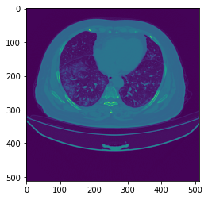

```python
plt.imshow(sample_ct[...,120]) ## plt.imshow(sample_ct[:,:,120] 와 같음
```

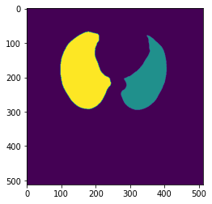

```python
plt.imshow(sample_lung[...,120])
```

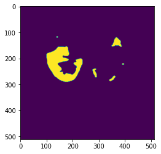

```python
plt.imshow(sample_infe[...,120])
```

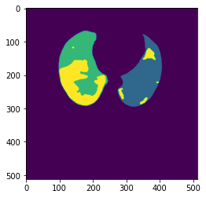

```python
plt.imshow(sample_all[...,120])
```

### Discussion with 하영

자료구조가 뭔가 시간순서로 배치된것 같음..

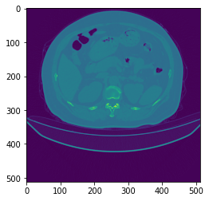

```python
plt.imshow(sample_ct[...,0])
```

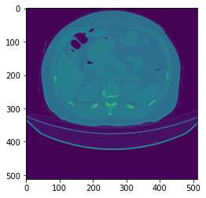

```python
plt.imshow(sample_ct[...,5])
```

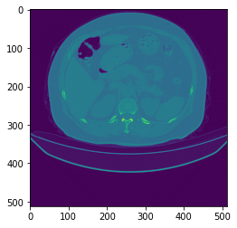

```python
plt.imshow(sample_ct[...,10])
```

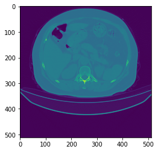

```python
plt.imshow(sample_ct[...,15])
```